# Final Project Part 2: Regression

Thomas Brusilovsky

2022-11-29

## Load packages

```r
library(tidyverse)
library(caret)
```

The code chunk below reads in the final project data.

```r
df <- readr::read_csv("fall2022_finalproject.csv", col_names = TRUE)
```

Next, we create a number of other relevant features

```r
df_new_cols <- df %>% mutate(x5 = (1 - (x1 + x2 + x3 + x4))) %>%
  mutate(w = x2 / (x3 + x4)) %>%
  mutate(z = (x1 + x2) / (x4 + x5)) %>%
  mutate(t = v1*v2) %>%
  mutate(transformed_output = boot::logit(output)) %>%
  mutate(binary = case_when(output < .33  ~ 'Event', output >=.33 ~ 'Non-Event'))
```

Now, before we can train our models we need to center and standardize our data.

```r
df_derived <- df_new_cols %>%
  purrr::keep(is.numeric) %>%
  scale() %>%
  bind_cols(df_new_cols %>% purrr::discard(is.numeric)) %>%
  select(all_of(names(df_new_cols)))
```

```r
df_derived %>% summary()
```

```
##        x1                 x2                x3                 x4
##  Min.   :-1.72358   Min.   :-1.5317   Min.   :-2.10525   Min.   :-1.9900
##  1st Qu.:-0.79161   1st Qu.:-0.9668   1st Qu.:-0.66845   1st Qu.:-0.7098
##  Median : 0.08819   Median : 0.1092   Median : 0.00712   Median : 0.1012
##  Mean   : 0.00000   Mean   : 0.0000   Mean   : 0.00000   Mean   : 0.0000
##  3rd Qu.: 0.57624   3rd Qu.: 0.7659   3rd Qu.: 0.65660   3rd Qu.: 0.7276
##  Max.   : 2.26171   Max.   : 2.7806   Max.   : 2.00544   Max.   : 1.8722
##        v1                 v2                 v3                 v4
##  Min.   :-1.87874   Min.   :-1.82989   Min.   :-1.84248   Min.   :-2.0207
##  1st Qu.:-0.64538   1st Qu.:-0.61769   1st Qu.:-0.65526   1st Qu.:-0.8101
##  Median : 0.02132   Median : 0.04372   Median : 0.02533   Median :-0.0089
##  Mean   : 0.00000   Mean   : 0.00000   Mean   : 0.00000   Mean   : 0.0000
##  3rd Qu.: 0.65548   3rd Qu.: 0.66339   3rd Qu.: 0.65379   3rd Qu.: 0.8049
##  Max.   : 1.87066   Max.   : 1.88398   Max.   : 1.85922   Max.   : 2.0855
##        v5               m                 output              x5
##  Min.   :-1.6744   Length:1252        Min.   :-1.6772   Min.   :-1.3512
##  1st Qu.:-0.9793   Class :character   1st Qu.:-0.8940   1st Qu.:-0.7512
##  Median : 0.1798   Mode  :character   Median :-0.1525   Median :-0.3858
##  Mean   : 0.0000                      Mean   : 0.0000   Mean   : 0.0000
##  3rd Qu.: 0.9890                      3rd Qu.: 0.9979   3rd Qu.: 0.5379
##  Max.   : 1.1807                      Max.   : 1.4971   Max.   : 3.5060
##        w                  z                  t            transformed_output
##  Min.   :-1.78840   Min.   :-1.46178   Min.   :-1.21451   Min.   :-2.3712
##  1st Qu.:-0.84523   1st Qu.:-0.89122   1st Qu.:-0.83296   1st Qu.:-0.7001
##  Median : 0.04584   Median :-0.07615   Median :-0.08334   Median :-0.2577
##  Mean   : 0.00000   Mean   : 0.00000   Mean   : 0.00000   Mean   : 0.0000
##  3rd Qu.: 0.84833   3rd Qu.: 0.72892   3rd Qu.: 0.42145   3rd Qu.: 0.4974
##  Max.   : 1.62811   Max.   : 2.17530   Max.   : 3.63536   Max.   : 2.7567
##     binary
##  Length:1252
##  Class :character
##  Mode  :character
##
##
##
```

## Linear Models

Before moving on to more advanced methods, we will use a number of linear models to establish a baseline. We will use the lm() function to fit nine such models.

# Training the models

Model 1: All linear additive features of the base features

```r
lin_mod1 <-lm(transformed_output ~ x1 + x2 + x3 + x4 + v1 + v2 + v3 + v4 + v5, data = df_derived)
```

Model 2: Interaction of the categorical input with all continuous inputs in the base features

```r
lin_mod2 <-lm(transformed_output ~ m*(x1 + x2 + x3 + x4 + v1 + v2 + v3 + v4 + v5), data = df_derived)
```

Model 3: All pair-wise interactions of the continuous inputs in the base features

```r
lin_mod3 <- lm(transformed_output ~ (x1 + x2 + x3 + x4 + v1 + v2 + v3 + v4 + v5) * (x1 + x2 + x3 + x4 + v1 + v2 + v3 + v4 + v5),data = df_derived)
```

Model 4: All linear additive features

```r
#x5 is not included as it is simply a combination of x1-4
lin_mod4 <- lm(transformed_output ~ . - m - output - binary -x5,data = df_derived)
```

Model 5: Interaction of the categorical input with all continuous features

```r
#x5 is not included as it is simply a combination of x1-4
lin_mod5 <- lm(transformed_output ~ m* (. - m - output - binary -x5),data = df_derived)
```

Model 6: Pair-wise interactions between the continuous features

```r
#x5 is not included as it is simply a combination of x1-4, v1:v2 is excluded as t = v1:v2
lin_mod6 <- lm(transformed_output ~  (. - m - output - binary -x5) * (. - m - output - binary -x5) - v1:v2,data = df_derived)
```

Model 7: All linear additive and quadratic features

```r
lin_mod7 <- lm(transformed_output ~ . - m - output - binary -x5 + I(x1^2) + I(x2^2) + I(x3^2) + I(x4^2) + I(v1^2) + I(v2^2) + I(v3^2) + I(v4^2) + I(v5^2) + I(w^2) + I(z^2) + I(t^2)  , data = df_derived)
```

Model 8: Sin of all continuous features in the base set

```r
lin_mod8 <- lm(transformed_output ~ sin(x1) + sin(x2) + sin(x3) + sin(x4) + sin(v1) + sin(v2) + sin(v3) + sin(v4) + sin(v5), data = df_derived )
```

Model 9: Interaction between some features from the base set

```r
#features are chosen from those found to be correlated during data exploration
lin_mod9 <- lm(transformed_output ~ x1*x2 + x1*x3 + x2*x3 + x3*x4 + x2*v4 + x1*v5 + x2*v5, data = df_derived)
```

#Assessing the models

One method by which we can judge which model is the most accurate is the adjusted R-Squared of the model. Adjusted R-Squared is similar to the R-squared value except it accounts for the number of variables. Thus, we extract the adjusted r-squared value of each of the nine models.

```r
summary(lin_mod1)$adj.r.squared
```

```
## [1] 0.0309559
```

```r
summary(lin_mod2)$adj.r.squared
```

```
## [1] 0.03324525
```

```r
summary(lin_mod3)$adj.r.squared
```

```
## [1] 0.08089363
```

```r
summary(lin_mod4)$adj.r.squared
```

```
## [1] 0.3793199
```

```r
summary(lin_mod5)$adj.r.squared
```

```
## [1] 0.3867404
```

```r
summary(lin_mod6)$adj.r.squared
```

```
## [1] 0.6862957
```

```r
summary(lin_mod7)$adj.r.squared
```

```
## [1] 0.6566877
```

```r
summary(lin_mod8)$adj.r.squared
```

```
## [1] 0.03547799
```

```r
summary(lin_mod9)$adj.r.squared
```

```
## [1] 0.06678582
```

By this metric, we see that model 6 is the best, with model 7 and model 5 having the two next highest adjusted R-Squared values.

# Coefficient Summaries

Now, we will look at the coefficient summaries and plots of the three best models.

Model 6:

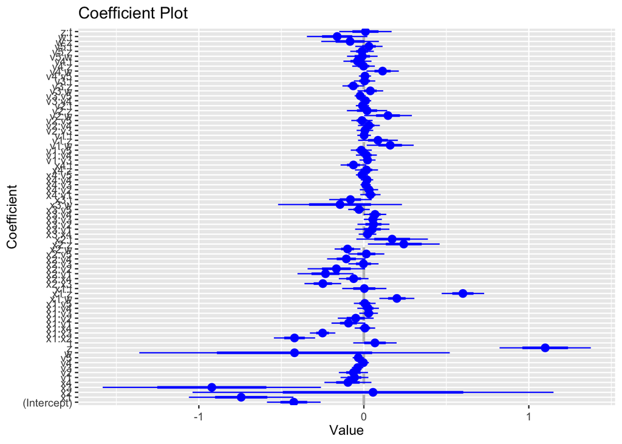

```r
lin_mod6 %>% coefplot::coefplot()
```

```r
summary(lin_mod6)
```

```
##
## Call:
## lm(formula = transformed_output ~ (. - m - output - binary -
##     x5) * (. - m - output - binary - x5) - v1:v2, data = df_derived)
##
## Residuals:
##      Min       1Q   Median       3Q      Max
## -1.45856 -0.36025 -0.00043  0.36359  2.33912
##
## Coefficients: (2 not defined because of singularities)
##              Estimate Std. Error t value Pr(>|t|)
## (Intercept) -0.424551   0.081290  -5.223 2.08e-07 ***
## x1          -0.743477   0.158319  -4.696 2.96e-06 ***
## x2           0.055749   0.547002   0.102 0.918840
## x3          -0.921447   0.330675  -2.787 0.005413 **
## x4          -0.096478   0.071160  -1.356 0.175428
## v1          -0.056835   0.042183  -1.347 0.178127
## v2          -0.063178   0.043983  -1.436 0.151155
## v3          -0.037869   0.017280  -2.192 0.028611 *
## v4          -0.002452   0.016679  -0.147 0.883169
## v5          -0.033496   0.017107  -1.958 0.050464 .
## w           -0.420099   0.470392  -0.893 0.371996
## z            1.099232   0.138287   7.949 4.38e-15 ***
## t            0.067224   0.065702   1.023 0.306440
## x1:x2       -0.420237   0.062446  -6.730 2.65e-11 ***
## x1:x3       -0.250043   0.038548  -6.486 1.29e-10 ***
## x1:x4        0.006706   0.031041   0.216 0.828995
## x1:v1       -0.093325   0.051262  -1.821 0.068928 .
## x1:v2       -0.049151   0.054388  -0.904 0.366327
## x1:v3        0.029027   0.028157   1.031 0.302794
## x1:v4        0.025948   0.032684   0.794 0.427416
## x1:v5        0.005487   0.032946   0.167 0.867763
## x1:w         0.200114   0.053015   3.775 0.000168 ***
## x1:z         0.600484   0.064359   9.330  < 2e-16 ***
## x1:t         0.002805   0.067008   0.042 0.966621
## x2:x3       -0.248484   0.055751  -4.457 9.11e-06 ***
## x2:x4       -0.061523   0.044963  -1.368 0.171477
## x2:v1       -0.232544   0.084781  -2.743 0.006183 **
## x2:v2       -0.166529   0.087195  -1.910 0.056396 .
## x2:v3       -0.002217   0.045767  -0.048 0.961378
```

[output cut: 40 more lines]

```
## v4:w         0.113698   0.049150   2.313 0.020879 *
## v4:z        -0.001691   0.034276  -0.049 0.960655
## v4:t        -0.038641   0.042483  -0.910 0.363249
## v5:w        -0.009377   0.046310  -0.202 0.839566
## v5:z        -0.010883   0.035767  -0.304 0.760975
## v5:t         0.030828   0.041369   0.745 0.456302
## w:z         -0.083479   0.087307  -0.956 0.339187
## w:t         -0.161836   0.091631  -1.766 0.077629 .
## z:t          0.009789   0.079341   0.123 0.901825
## ---
## Signif. codes:  0 '***' 0.001 '**' 0.01 '*' 0.05 '.' 0.1 ' ' 1
##
## Residual standard error: 0.5601 on 1176 degrees of freedom
## Multiple R-squared:  0.7051, Adjusted R-squared:  0.6863
## F-statistic: 37.49 on 75 and 1176 DF,  p-value: < 2.2e-16
```

Model 7:

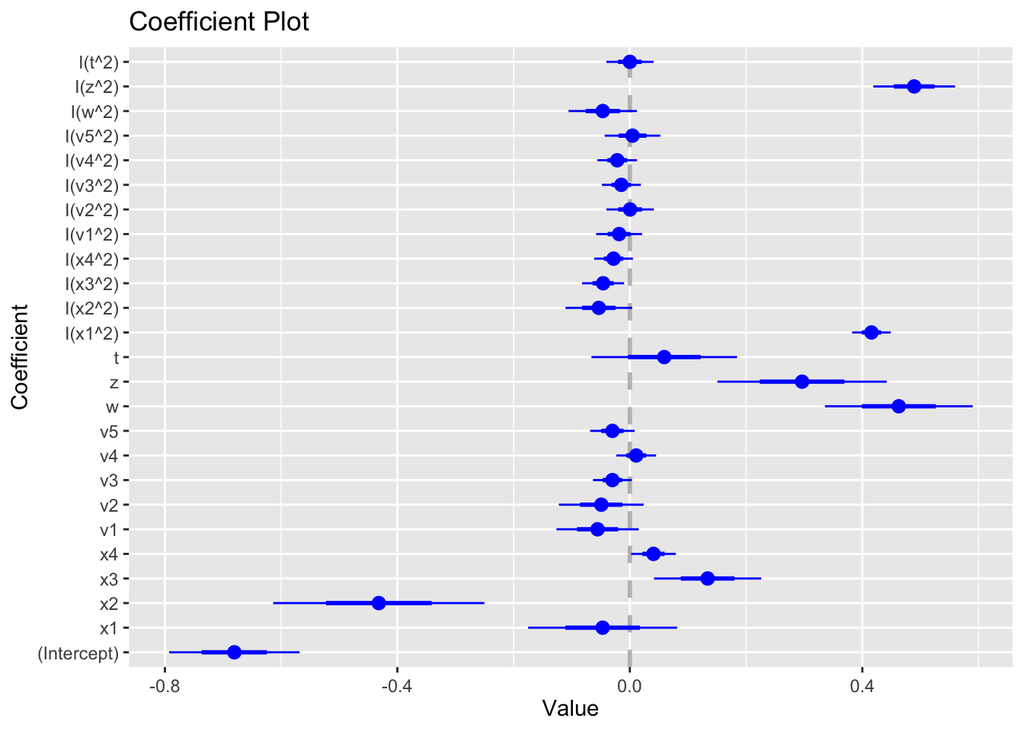

```r
lin_mod7 %>% coefplot::coefplot()
```

```r
summary(lin_mod7)
```

```
##
## Call:
## lm(formula = transformed_output ~ . - m - output - binary - x5 +
##     I(x1^2) + I(x2^2) + I(x3^2) + I(x4^2) + I(v1^2) + I(v2^2) +
##     I(v3^2) + I(v4^2) + I(v5^2) + I(w^2) + I(z^2) + I(t^2), data = df_derived)
##
## Residuals:
##     Min      1Q  Median      3Q     Max
## -1.7185 -0.3852  0.0049  0.3835  2.3621
##
## Coefficients:
##               Estimate Std. Error t value Pr(>|t|)
## (Intercept) -0.6805094  0.0561516 -12.119  < 2e-16 ***
## x1          -0.0468066  0.0640765  -0.730  0.46524
## x2          -0.4319296  0.0908781  -4.753 2.24e-06 ***
## x3           0.1338617  0.0461292   2.902  0.00378 **
## x4           0.0406608  0.0191594   2.122  0.03402 *
## v1          -0.0555479  0.0353980  -1.569  0.11685
## v2          -0.0491555  0.0364652  -1.348  0.17790
## v3          -0.0300442  0.0167459  -1.794  0.07304 .
## v4           0.0109075  0.0171292   0.637  0.52439
## v5          -0.0299997  0.0191760  -1.564  0.11797
## w            0.4627523  0.0635616   7.280 5.93e-13 ***
## z            0.2963366  0.0728280   4.069 5.02e-05 ***
## t            0.0591747  0.0626530   0.944  0.34511
## I(x1^2)      0.4157169  0.0166327  24.994  < 2e-16 ***
## I(x2^2)     -0.0533832  0.0286703  -1.862  0.06285 .
## I(x3^2)     -0.0459909  0.0180879  -2.543  0.01112 *
## I(x4^2)     -0.0280552  0.0166985  -1.680  0.09319 .
## I(v1^2)     -0.0184547  0.0197482  -0.935  0.35023
## I(v2^2)      0.0004204  0.0204422   0.021  0.98359
## I(v3^2)     -0.0147035  0.0167639  -0.877  0.38061
## I(v4^2)     -0.0217552  0.0170753  -1.274  0.20288
## I(v5^2)      0.0045736  0.0239628   0.191  0.84866
## I(w^2)      -0.0466121  0.0294646  -1.582  0.11391
## I(z^2)       0.4891957  0.0351296  13.925  < 2e-16 ***
## I(t^2)       0.0001016  0.0203020   0.005  0.99601
## ---
## Signif. codes:  0 '***' 0.001 '**' 0.01 '*' 0.05 '.' 0.1 ' ' 1
##
## Residual standard error: 0.5859 on 1227 degrees of freedom
## Multiple R-squared:  0.6633, Adjusted R-squared:  0.6567
## F-statistic: 100.7 on 24 and 1227 DF,  p-value: < 2.2e-16
```

Model 5:

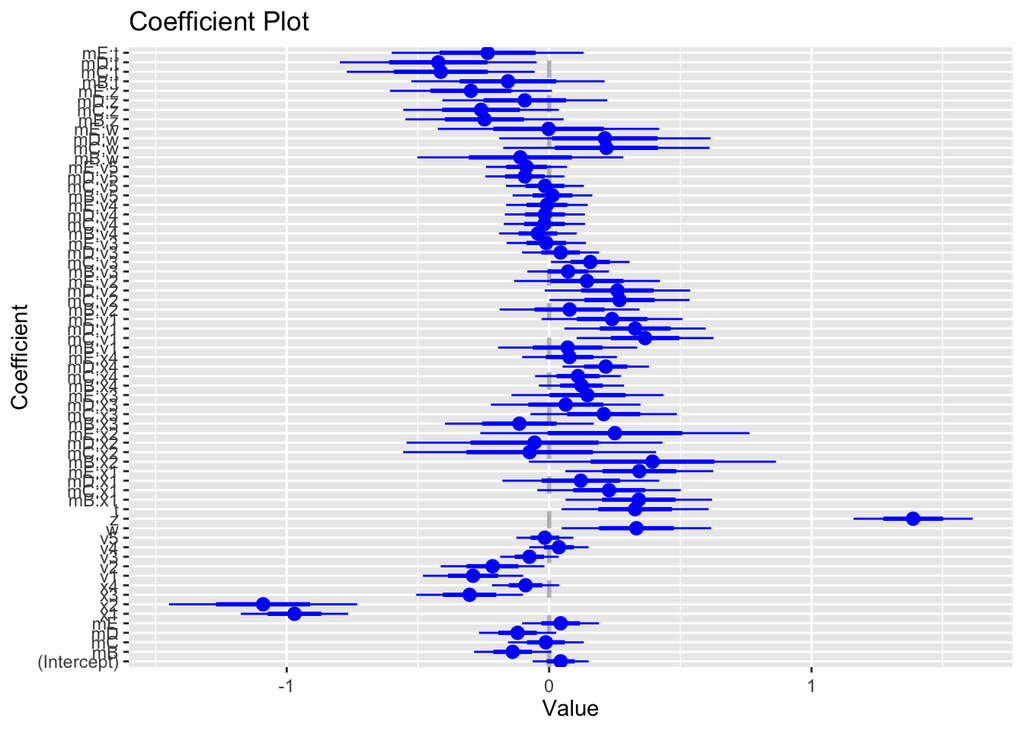

```r
lin_mod5 %>% coefplot::coefplot()
```

```r
summary(lin_mod5)
```

```
##
## Call:
## lm(formula = transformed_output ~ m * (. - m - output - binary -
##     x5), data = df_derived)
##
## Residuals:
##     Min      1Q  Median      3Q     Max
## -2.2379 -0.5056 -0.0834  0.3907  3.3948
##
## Coefficients:
##              Estimate Std. Error t value Pr(>|t|)
## (Intercept)  0.043954   0.053339   0.824  0.41007
## mB          -0.139052   0.073502  -1.892  0.05876 .
## mC          -0.012463   0.072058  -0.173  0.86272
## mD          -0.120298   0.073447  -1.638  0.10171
## mE           0.043794   0.073292   0.598  0.55027
## x1          -0.970684   0.102318  -9.487  < 2e-16 ***
## x2          -1.090193   0.179144  -6.086 1.56e-09 ***
## x3          -0.303078   0.101656  -2.981  0.00293 **
## x4          -0.089843   0.064086  -1.402  0.16120
## v1          -0.290016   0.095406  -3.040  0.00242 **
## v2          -0.215483   0.098893  -2.179  0.02953 *
## v3          -0.075106   0.055708  -1.348  0.17785
## v4           0.037240   0.056594   0.658  0.51065
## v5          -0.016290   0.054236  -0.300  0.76396
## w            0.332735   0.142503   2.335  0.01971 *
## z            1.387176   0.113579  12.213  < 2e-16 ***
## t            0.327584   0.140089   2.338  0.01953 *
## mB:x1        0.341769   0.139572   2.449  0.01448 *
## mC:x1        0.228403   0.136766   1.670  0.09518 .
## mD:x1        0.120716   0.149507   0.807  0.41958
## mE:x1        0.343769   0.140874   2.440  0.01482 *
## mB:x2        0.393819   0.235404   1.673  0.09460 .
## mC:x2       -0.074293   0.241075  -0.308  0.75800
## mD:x2       -0.055561   0.243796  -0.228  0.81976
## mE:x2        0.250708   0.256466   0.978  0.32850
## mB:x3       -0.113541   0.141664  -0.801  0.42301
## mC:x3        0.208105   0.139566   1.491  0.13620
## mD:x3        0.063209   0.142499   0.444  0.65743
## mE:x3        0.146062   0.144870   1.008  0.31355
```

[output cut: 27 more lines]

```
## mE:w        -0.002073   0.211087  -0.010  0.99217
## mB:z        -0.246395   0.150724  -1.635  0.10237
## mC:z        -0.259368   0.148233  -1.750  0.08042 .
## mD:z        -0.092850   0.157164  -0.591  0.55478
## mE:z        -0.298149   0.154175  -1.934  0.05337 .
## mB:t        -0.156943   0.184128  -0.852  0.39419
## mC:t        -0.413151   0.178936  -2.309  0.02112 *
## mD:t        -0.422612   0.187612  -2.253  0.02447 *
## mE:t        -0.234396   0.182846  -1.282  0.20012
## ---
## Signif. codes:  0 '***' 0.001 '**' 0.01 '*' 0.05 '.' 0.1 ' ' 1
##
## Residual standard error: 0.7831 on 1187 degrees of freedom
## Multiple R-squared:  0.4181, Adjusted R-squared:  0.3867
## F-statistic: 13.33 on 64 and 1187 DF,  p-value: < 2.2e-16
```

In each of the three models, we can see that there are only a small number of significant inputs. Model 7 uses the fewest inputs and while model 6 uses the most. Looking at the three models, we find a few of the most significant inputs, those where the error does not include 0. These inputs include x1, x2, x3, x4, w, x1^2, and x1:z.

## Bayesian Linear Models

Now, we will fit two Bayesian linear models. The models we will use are models 6 and 7. 6 was our best model from the previous section, while 7 was a close second so it is also chosen. To fit these models, we will use functions from the rstanarm package which we must thus import.

```r
library(rstanarm)
```

We will use a fairly neutral prior R^2 value of .5.

```r
bays_mod6 <- stan_lm(transformed_output ~  (. - m - output - binary -x5) * (. - m - output - binary -x5) - v1:v2,data = df_derived, prior = R2(location = .5),
                 seed = 432123)
bays_mod7 <- stan_lm(transformed_output ~ . - m - output - binary -x5 + I(x1^2) + I(x2^2) + I(x3^2) + I(x4^2) + I(v1^2) + I(v2^2) + I(v3^2) + I(v4^2) + I(v5^2) + I(w^2) + I(z^2) + I(t^2)  , data = df_derived,prior = R2(location = .5),
                 seed = 432123)
summary(bays_mod6)
```

```
##
## Model Info:
##  function:     stan_lm
##  family:       gaussian [identity]
##  formula:      transformed_output ~ (. - m - output - binary - x5) * (. - m -
##     output - binary - x5) - v1:v2
##  algorithm:    sampling
##  sample:       4000 (posterior sample size)
##  priors:       see help('prior_summary')
##  observations: 1252
##  predictors:   76
##
## Estimates:
##                 mean   sd   10%   50%   90%
## (Intercept)   -0.4    0.1 -0.5  -0.4  -0.3
## x1            -0.7    0.2 -0.9  -0.7  -0.5
## x2             0.0    0.6 -0.7   0.0   0.8
## x3            -0.9    0.3 -1.3  -0.9  -0.4
## x4            -0.1    0.1 -0.2  -0.1   0.0
## v1            -0.1    0.0 -0.1  -0.1   0.0
## v2            -0.1    0.0 -0.1  -0.1   0.0
## v3             0.0    0.0 -0.1   0.0   0.0
## v4             0.0    0.0  0.0   0.0   0.0
## v5             0.0    0.0 -0.1   0.0   0.0
## w             -0.4    0.5 -1.0  -0.4   0.2
## z              1.1    0.1  0.9   1.1   1.2
## t              0.1    0.1  0.0   0.1   0.1
## x1:x2         -0.4    0.1 -0.5  -0.4  -0.3
## x1:x3         -0.2    0.0 -0.3  -0.2  -0.2
## x1:x4          0.0    0.0  0.0   0.0   0.0
## x1:v1         -0.1    0.1 -0.2  -0.1   0.0
## x1:v2          0.0    0.1 -0.1   0.0   0.0
## x1:v3          0.0    0.0  0.0   0.0   0.1
## x1:v4          0.0    0.0  0.0   0.0   0.1
## x1:v5          0.0    0.0  0.0   0.0   0.0
## x1:w           0.2    0.1  0.1   0.2   0.3
## x1:z           0.6    0.1  0.5   0.6   0.7
## x1:t           0.0    0.1 -0.1   0.0   0.1
## x2:x3         -0.2    0.1 -0.3  -0.2  -0.2
## x2:x4         -0.1    0.0 -0.1  -0.1   0.0
```

[output cut: 130 more lines]

```
## v4:z          0.0  1.0  6001
## v4:t          0.0  1.0  5731
## v5:w          0.0  1.0  5179
## v5:z          0.0  1.0  4625
## v5:t          0.0  1.0  5336
## w:z           0.0  1.0  3670
## w:t           0.0  1.0  5627
## z:t           0.0  1.0  5020
## sigma         0.0  1.0  5917
## log-fit_ratio 0.0  1.0  4827
## R2            0.0  1.0  4392
## mean_PPD      0.0  1.0  3905
## log-posterior 0.3  1.0   775
##
## For each parameter, mcse is Monte Carlo standard error, n_eff is a crude measure of effective sample size, and Rhat is the potential scale reduction factor on split chains (at convergence Rhat=1).
```

```r
summary(bays_mod7)
```

```
##
## Model Info:
##  function:     stan_lm
##  family:       gaussian [identity]
##  formula:      transformed_output ~ . - m - output - binary - x5 + I(x1^2) +
##     I(x2^2) + I(x3^2) + I(x4^2) + I(v1^2) + I(v2^2) + I(v3^2) +
##     I(v4^2) + I(v5^2) + I(w^2) + I(z^2) + I(t^2)
##  algorithm:    sampling
##  sample:       4000 (posterior sample size)
##  priors:       see help('prior_summary')
##  observations: 1252
##  predictors:   25
##
## Estimates:
##                 mean   sd   10%   50%   90%
## (Intercept)   -0.7    0.1 -0.7  -0.7  -0.6
## x1             0.0    0.1 -0.1   0.0   0.0
## x2            -0.4    0.1 -0.5  -0.4  -0.3
## x3             0.1    0.0  0.1   0.1   0.2
## x4             0.0    0.0  0.0   0.0   0.1
## v1            -0.1    0.0 -0.1  -0.1   0.0
## v2             0.0    0.0 -0.1   0.0   0.0
## v3             0.0    0.0 -0.1   0.0   0.0
## v4             0.0    0.0  0.0   0.0   0.0
## v5             0.0    0.0 -0.1   0.0   0.0
## w              0.5    0.1  0.4   0.5   0.5
## z              0.3    0.1  0.2   0.3   0.4
## t              0.1    0.1  0.0   0.1   0.1
## I(x1^2)        0.4    0.0  0.4   0.4   0.4
## I(x2^2)       -0.1    0.0 -0.1  -0.1   0.0
## I(x3^2)        0.0    0.0 -0.1   0.0   0.0
## I(x4^2)        0.0    0.0  0.0   0.0   0.0
## I(v1^2)        0.0    0.0  0.0   0.0   0.0
## I(v2^2)        0.0    0.0  0.0   0.0   0.0
## I(v3^2)        0.0    0.0  0.0   0.0   0.0
## I(v4^2)        0.0    0.0  0.0   0.0   0.0
## I(v5^2)        0.0    0.0  0.0   0.0   0.0
## I(w^2)         0.0    0.0 -0.1   0.0   0.0
## I(z^2)         0.5    0.0  0.4   0.5   0.5
## I(t^2)         0.0    0.0  0.0   0.0   0.0
```

[output cut: 29 more lines]

```
## I(v1^2)       0.0  1.0  5854
## I(v2^2)       0.0  1.0  5342
## I(v3^2)       0.0  1.0  5020
## I(v4^2)       0.0  1.0  4508
## I(v5^2)       0.0  1.0  4829
## I(w^2)        0.0  1.0  5352
## I(z^2)        0.0  1.0  5527
## I(t^2)        0.0  1.0  5691
## sigma         0.0  1.0  7226
## log-fit_ratio 0.0  1.0  4932
## R2            0.0  1.0  4325
## mean_PPD      0.0  1.0  3930
## log-posterior 0.2  1.0   561
##
## For each parameter, mcse is Monte Carlo standard error, n_eff is a crude measure of effective sample size, and Rhat is the potential scale reduction factor on split chains (at convergence Rhat=1).
```

Now let us try to compare the two models by looking at their waic values.

```r
bays_mod6$waic <- waic(bays_mod6)
bays_mod7$waic <- waic(bays_mod7)
bays_mod6$waic
```

```
##
## Computed from 4000 by 1252 log-likelihood matrix
##
##           Estimate    SE
## elpd_waic  -3723.2 304.7
## p_waic      2217.2 278.6
## waic        7446.4 609.3
##
## 490 (39.1%) p_waic estimates greater than 0.4. We recommend trying loo instead.
```

```r
bays_mod7$waic
```

```
##
## Computed from 4000 by 1252 log-likelihood matrix
##
##           Estimate   SE
## elpd_waic  -1123.7 28.7
## p_waic        30.3  1.9
## waic        2247.5 57.4
##
## 5 (0.4%) p_waic estimates greater than 0.4. We recommend trying loo instead.
```

Looking at the waic values, we can clearly see that model 7 is better than model 6.